# Task 3: Santa Barbara Urchins

Julia Wilson

10/23/2021

### Overview

In this task we wrangle, analyze, and visualize data about red and purple sea urchins recorded by Santa Barbara Coastal Long Term Ecological Research program divers.

**Data Citation:** Reed, LTER: Reef:Long-term experiment:Kelop removal: Urchin size frequency distribution ver 20. Environmental Data Initiative. https://doi.org/10.6073/pasta/5a1e9ef03aa47bd2225c0bb98a02a63b.

### Setup

```r
knitr::opts_chunk$set(echo = TRUE, message = FALSE, warning = FALSE)

# Attach Packages
library(here)
library(tidyverse)
library(janitor)
library(lubridate)
library(kableExtra)
```

## Section 1

### Read in the Data

```r
# Read in urchins.csv data and name "urchins_data"
urchins_data <- read_csv(here("data", "urchins.csv"))
```

### Clean Data using clean_names()

```r
urchins_clean <- urchins_data %>%
  clean_names()
```

### Visualize Data: Compare the distribution sizes between purple and red urchins

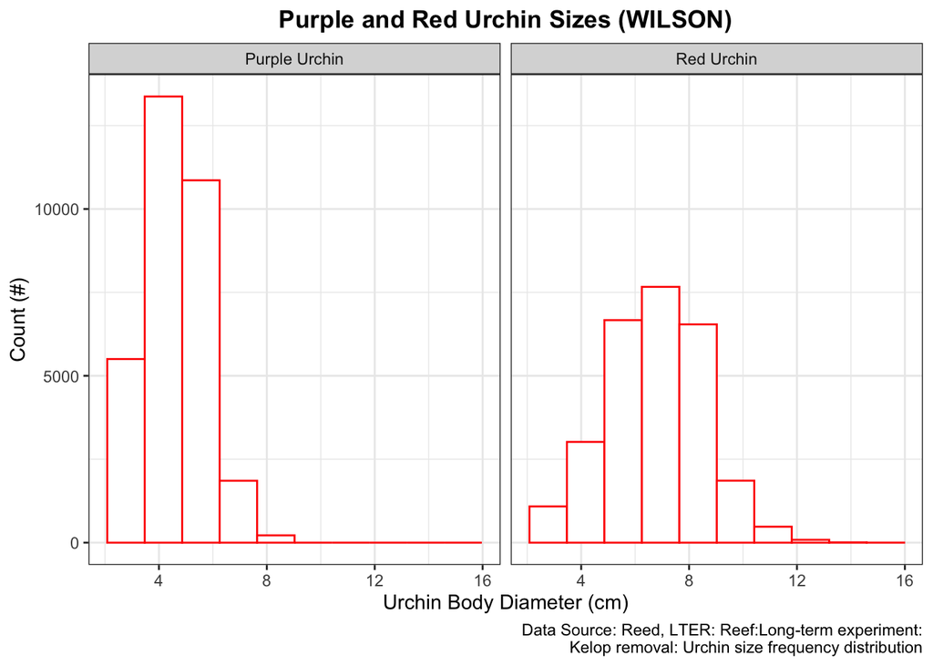

```r
ggplot(data = urchins_clean, aes(x = size)) +
  geom_histogram(color = "red", fill = "white", bins = 10) +
  facet_wrap(~common_name) +
  labs(x = "Urchin Body Diameter (cm)",
       y = "Count (#)",
       title = "Purple and Red Urchin Sizes (WILSON)",
       caption = "Data Source: Reed, LTER: Reef:Long-term experiment:
       Kelop removal: Urchin size frequency distribution") +
  theme_bw() +
  theme(plot.title = element_text(hjust = 0.5, face = "bold"))
```

**Figure 1: Purple and Red Urchin Sizes** Compares the distribution of body diameters (cm) between purple and red urchins. Purple urchin body diameters (cm) have a lower tendency, smaller distribution, and spread than Red Urchins.

### Descriptive Statistics Table: Create a finalized summary table that contains mean, median, standard deviation, and sample size for purple and red urchins

```r
# Create a finalized summary table using kableEXTRA
urchins_summary <- urchins_clean %>%
  group_by(common_name) %>%
  summarize(mean = mean(size, na.rm = TRUE),
            median = median(size, na.rm = TRUE),
            sd = sd(size, na.rm = TRUE),
            sample_size = n()) %>%
  kable(caption = "Table 1: Urchin Body Diameters (cm) Summary Statistics",
        col.names = c("Urchin Name",
                      "Mean (cm)",
                      "Median (cm)",
                      "Standard Deviation (cm)",
                      "Sample Size"),
        digits = 1) %>%
  kable_minimal(html_font = "Georgia", font_size = 12, full_width = FALSE) %>%
  kable_material(c("striped", "hover", "condensed"))

urchins_summary
```

Table 1: Urchin Body Diameters (cm) Summary Statistics

| Urchin Name | Mean (cm) | Median (cm) | Standard Deviation (cm) | Sample Size |
| --- | --- | --- | --- | --- |
| Purple Urchin | 4.5 | 4.5 | 1.2 | 31805 |
| Red Urchin | 6.8 | 7.0 | 1.9 | 27408 |

**Table 1: Urchin Body Diameters (cm) Summary Statistics** This table compares red urchins (n=27,408) and purple urchins (n=31,805) body diameters (cm) by mean, median, standard deviation, and sample size.

**Conclusion:** The purple urchins have a mean value of 4.5 (cm), which is 2.3 (cm) less than the red urchin’s mean value. This a 40.7% difference between mean values. The purple urchins also have a smaller central tendency and spread; their standard deviation is 1.2 (cm), which is 0.7 (cm) less than the red urchin’s standard deviation. This is a 45.2% difference between standard deviation.

## Section 2

### Wrangle Data: Create a data subset that only includes purple urchins. Change dates to mdy format and change site names to full descriptions

```r
purple_urchins <- urchins_clean %>%
  filter(common_name == "Purple Urchin") %>%
  mutate(date_new = mdy(date)) %>%
  mutate(year_new = year(date_new)) %>%
  mutate(site_full = case_when(
    site == "NAPL" ~ "Naples Reef",
    site == "MOHK" ~ "Mohawk Reef",
    site == "IVEE" ~ "Isla Vista Reef",
    site == "AQUE" ~ "Arroyo Quemado Reef",
    site == "CARP" ~ "Carpinteria Reef"))
```

### Descriptive Statistics Table: Store a summary table containing total number of purple urchins observed by site and year

```r
purple_urchin_summary <- purple_urchins %>%
  group_by(site_full, year_new) %>%
  summarize(sample_size = n())

purple_urchin_summary
```

```
## # A tibble: 61 × 3
## # Groups:   site_full [5]
##    site_full           year_new sample_size
##    <chr>                  <dbl>       <int>
##  1 Arroyo Quemado Reef     2008          67
##  2 Arroyo Quemado Reef     2009         926
##  3 Arroyo Quemado Reef     2010         921
##  4 Arroyo Quemado Reef     2011         887
##  5 Arroyo Quemado Reef     2012         764
##  6 Arroyo Quemado Reef     2013         434
##  7 Arroyo Quemado Reef     2014         410
##  8 Arroyo Quemado Reef     2015         400
##  9 Arroyo Quemado Reef     2016         342
## 10 Arroyo Quemado Reef     2017         406
## # … with 51 more rows
```

### Visualize Data: Compare purple urchin counts at each site from 2008 - 2020

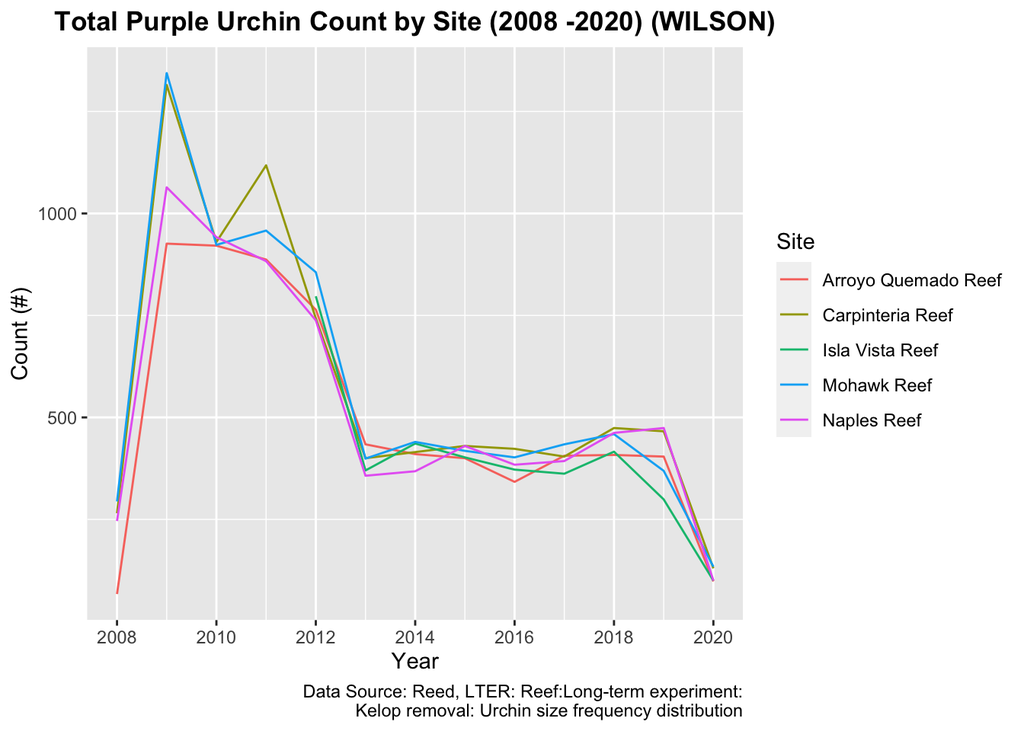

```r
ggplot(data = purple_urchin_summary,
       aes(x = year_new, y = sample_size, color = site_full)) +
  geom_line(size = 0.5) +
  scale_x_continuous(breaks = c(2008, 2010, 2012, 2014, 2016, 2018, 2020)) +
  labs(x = "Year",
       y = "Count (#)",
       title = "Total Purple Urchin Count by Site (2008 -2020) (WILSON)",
       fill = "Site",
       caption = "Data Source: Reed, LTER: Reef:Long-term experiment:
       Kelop removal: Urchin size frequency distribution",
       color = "Site") +
  theme(plot.title = element_text(hjust = 0.5, face = "bold"))
```

**Analysis:** There is a possibility that this graph accurately reflects changes in the purple urchin population. However, you would need to take the sample size into account to determine the accuracy. In general, the larger the sample size, the higher the confidence level. We could apply a t test to determine if there is a significant difference between the sample mean and the population mean.

The changes in the number of purple urchins observed could be explained by an inaccurate representation of data because of the small sample size and/or recorded inaccurately due to human error.

## End Task 3